# PSCI 2300 Midterm 1

YOUR VUNETID HERE:

2026-09-25

# PRACTICE MIDTERM 1: PSCI 2300

This is closed book and closed notes. You are not to work or talk with anyone about the exam.

There are 43 multiple-choice questions and 8 written questions, including the questions in the Coding and Decoding section.

The actual exam would be shorter, but contain similar type questions.

## Multiple Choice

Choose the best answer for each question unless instructed to choose all that apply. Assume `tidyverse` is loaded and datasets are ungrouped unless stated otherwise.

### Question 1

What is a categorical variable?

**A.** A variable that represents numerical data.

**B.** A variable that can take on a finite number of distinct categories or groups.

**C.** A variable that measures the magnitude or size of something.

**D.** A variable that is used only in machine learning models.

### Question 2

In the context of resampling, what is the purpose of using `set.seed`?

**A.** To control the randomization process and ensure reproducibility of results.

**B.** To increase the size of each resampled dataset.

**C.** To remove missing values from the dataset.

**D.** To compute the mean and standard deviation of the data.

### Question 3

In R, what is the primary purpose of using the `glimpse` function when examining a data frame?

**A.** To generate a summary statistic of the data frame.

**B.** To visualize the data frame using a scatterplot.

**C.** To display the first few rows of the data frame.

**D.** To provide a concise overview of the data structure, including column names, data types, and a sample of rows.

### Question 4

What is the primary purpose of using the `mutate` function when data wrangling in tidyverse?

**A.** To generate summary statistics for a dataset.

**B.** To create a new column or modify existing columns based on calculations or transformations.

**C.** To filter rows based on specified conditions.

**D.** To reshape the data frame by changing the order of columns.

### Question 5

All of the following are statistical measures of central tendency (a “typical” value) *except*:

**A.** Mean

**B.** Median

**C.** Range

**D.** Mode

### Question 6

In R, what is the primary purpose of the pipe command (`|>`)?

**A.** To send the output to the Console window.

**B.** To combine multiple steps into a single sequence.

**C.** To choose rows in a dataset based on a specific condition.

**D.** To delete variables from a dataset.

### Question 7

What is the key distinction between `==` and `=`, and when would you use each?

**A.** Both `==` and `=` can be used for assigning variables.

**B.** `==` is used for variable assignment, while `=` is used for logical comparisons.

**C.** `==` is used for logical comparisons between two values, while `=` is used for variable assignment.

**D.** `=` is used for logical comparisons between two values, while `==` is used for variable assignment.

### Question 8

What is a continuous variable?

**A.** A variable that can only take on discrete, whole-number values.

**B.** A variable that represents categories or groups.

**C.** A variable that can take on an infinite number of possible values within a specified range.

**D.** A variable that is only used in machine learning models.

### Question 9

In R, what is the primary purpose of using the `summary` function when examining a data frame?

**A.** To graphically visualize the data.

**B.** To generate a brief statistical summary of the data.

**C.** To filter and subset the data based on provided criteria.

**D.** To calculate the relationship between two variables.

### Question 10

What is the primary purpose of using the `if_else` function when wrangling?

**A.** To create a new variable based on a logical condition.

**B.** To perform mathematical calculations on numeric vectors.

**C.** To remove missing values from a dataset.

**D.** To rename a set of variables in a dataset all at once.

### Question 11

What is the key difference between the `&` and `|`?

**A.** The & operator returns TRUE only if both are TRUE, while the | operator returns TRUE if either is TRUE.

**B.** The & operator returns TRUE if either is TRUE, while the | operator returns TRUE only if both are TRUE.

**C.** The & operator is used for addition, while the | operator is used for division.

**D.** The & operator is used for multiplication, while the | operator is used for subtraction.

### Question 12

Why do we use code rather than editing data by hand in a spreadsheet?

**A.** Code is always faster to write.

**B.** Spreadsheets cannot calculate averages.

**C.** Code records every step.

**D.** Code prevents all errors.

### Question 13

The variable `validated` is coded 1 = voted, 0 = did not vote, and -99 = not matched to the voter file. `mean(validated)` returns -21.4. What is the best explanation?

**A.** R treated -99 as a real number.

**B.** Most respondents did not vote.

**C.** R cannot calculate the mean.

**D.** The dataset has too many observations.

### Question 14

Which command replaces -99 with a missing value **and** saves the change in `ces`?

**A.** `ces |> mutate(validated = if_else(validated == -99, NA, validated))`

**B.** `ces = ces |> mutate(validated = if_else(validated = -99, NA, validated))`

**C.** `ces = ces |> mutate(validated = if_else(validated == -99, NA, validated))`

**D.** `ces = ces |> filter(validated == -99)`

### Question 15

`HarrisVoter` equals 1 for respondents who reported voting for Harris and 0 for respondents who reported voting for Trump. `mean(HarrisVoter)` is 0.56. What does 0.56 mean?

**A.** 56% of the respondents in these data reported voting for Harris.

**B.** Harris won 56% of the national vote.

**C.** The average respondent is 0.56 of a Harris voter.

**D.** 56 respondents reported voting for Harris.

### Question 16

`mean(av_products_clean)` returns `NA`. What should you do first?

**A.** Add `na.rm = TRUE`.

**B.** Inspect which observations are missing and why.

**C.** Replace every missing value with 0.

**D.** Delete the variable.

### Question 17

There are 101 districts, coded 1 = Toss-up, 2 = Lean, 3 = Likely, and 4 = Safe, with no missing values. These categories are ordered, but the gaps between categories are not assumed equal. Which functions can describe the category frequencies or the middle ordered category without assuming equal gaps? Choose all that apply.

**A.** `count()`

**B.** `mean()`

**C.** `median()`

**D.** `sum()`

### Question 18

The variable `age` ranges from 18 to 92, with no missing values. Which functions directly calculate a measure of its center? Choose all that apply.

**A.** `count()`

**B.** `mean()`

**C.** `median()`

**D.** `sum()`

### Question 19

The dataset has a column called `Q12`. Which command changes its name to `trust` and saves the result?

**A.** `survey = survey |> rename(trust = Q12)`

**B.** `survey |> rename(trust = Q12)`

**C.** `survey = survey |> mutate(trust == Q12)`

**D.** `survey = survey |> rename(Q12 = trust)`

### Question 20

A 95% bootstrap interval for **urban minus rural** average trust is `[-9, -2]` on a 0-100 scale. What does it suggest, assuming the sampling approach is appropriate?

**A.** There is no evidence of a difference because both endpoints are negative.

**B.** Living in a rural area causes greater trust than living in a urban area.

**C.** Urban trust is higher by between 2 and 9 points.

**D.** Urban trust is lower, and distinguishable from zero.

### Question 21

An analyst runs `quantile(survey$hours, p = .5)` and gets `12`. What has been calculated?

**A.** The median number of hours.

**B.** The average number of hours.

**C.** The width of a 95% bootstrap interval.

**D.** The percentage of respondents reporting exactly 12 hours.

### Question 22

`attended` contains `1, 0, 1, 1, 0`, with 1 meaning attended a town meeting. What does `sum(attended)` return?

**A.** 0.6, the proportion who attended.

**B.** 60, the percent who attended.

**C.** 5, the number of respondents.

**D.** 3, the number who attended.

### Question 23

You want to keep all rows but only the columns `city` and `population`. Which command does this?

**A.** `cities |> select(city, population)`

**B.** `cities |> count(city, population)`

**C.** `cities |> filter(city, population)`

**D.** `cities |> arrange(city, population)`

### Question 24

Which condition keeps respondents who are **either under 25 or at least 65**?

**A.** `filter(age <= 25 & age > 65)`

**B.** `filter(age < 25 | age >= 65)`

**C.** `filter(age < 25 & age >= 65)`

**D.** `filter(age < 25 | age < 65)`

**A.** `cities == readRDS("cities.rds")`

**B.** `saveRDS(cities, "cities.rds")`

**C.** `cities = read.csv("cities.csv")`

**D.** `cities = readRDS("cities.csv")`

### Question 26

Each row of `cities` describes one city. `dim(cities)` returns `900 12`. What does that tell you?

**A.** There are 900 cities and 12 variables.

**B.** There are 900 residents in each of 12 cities.

**C.** There are 900 variables measured for 12 cities.

**D.** There are 912 observations.

### Question 27

A poll’s 95% bootstrap interval for Harris support runs from 55% to 57%, but her actual share was 48%. What is the best explanation?

**A.** We did not use enough bootstrap samples when computing the interval.

**B.** The poll had too many respondents.

**C.** The interval must have been calculated incorrectly.

**D.** The interval reflects only variation due to random sampling.

### Question 28

When you ask an AI to “red-team” your argument, you are asking it to:

**A.** Agree with your argument and add supporting evidence.

**B.** Rewrite the argument in more formal language.

**C.** Retrain the model on your argument.

**D.** Look for weaknesses, objections, and alternative explanations.

### Question 29

What does `poll$age` refer to?

**A.** The dataset `age` stored inside the variable `poll`.

**B.** The number of respondents in `poll`.

**C.** The variable `age` in the dataset `poll`.

**D.** Only respondents with non-missing `age` .

### Question 30

Inside the loop, what is the purpose of this command?

```r
SampledHarrisSupport = bind_rows(SampledHarrisSupport, one_estimate)
```

**A.** To combine all the respondents from every sample into one large dataset.

**B.** To add the newest estimate as another row while keeping earlier estimates.

**C.** To replace all earlier estimates with only the newest estimate.

**D.** To calculate the average of the estimates already stored.

### Question 31

Which function belongs in the blank to give toss-up districts a shift of 5 and all other districts a shift of 0?

```r
cd = cd |>
  mutate(shift = ______(competitive_2026map == "Toss-up (<5)", 5, 0))
```

**A.** `if_else`

**B.** `filter`

**C.** `summarize`

**D.** `group_by`

### Question 32

If I want to create a new variable in my dataset, which function do I use?

**A.** `addvar()`

**B.** `mutate()`

**C.** `create()`

**D.** `case_when()`

### Question 33

In R, what is the primary purpose of using the `View()` function when examining a data frame?

**A.** To calculate summary statistics for each variable.

**B.** To display only the first six rows in the Console.

**C.** To open the data frame in a spreadsheet-style viewer for inspection.

**D.** To create a graph showing the distribution of each variable.

### Question 34

Suppose you want to calculate mean support separately for each party in the dataset `survey`. Which code snippet would do that?

**A.**

```r
survey |>
  summarize(MeanSupport = mean(support, na.rm = TRUE))
```

**B.**

```r
survey |>
  group_by(party) |>
  summarize(MeanSupport = mean(support, na.rm = TRUE))
```

**C.**

```r
survey |>
  group_by(support) |>
  summarize(MeanSupport = mean(party, na.rm = TRUE))
```

**D.**

```r
survey |>
  arrange(party) |>
  summarize(MeanSupport = mean(support, na.rm = TRUE))
```

### Question 35

You want to calculate the proportion who voted separately for each education category in `survey`. The variable `voted` is coded 1 = voted and 0 = did not vote, with no missing values. A classmate suggests first using `summarize(Turnout = mean(voted))` and then using `group_by(Education)`. What is the problem with this order?

**A.** `mean()` cannot be used with a variable coded 0 and 1.

**B.** Summarizing the ungrouped data first produces one overall turnout proportion and drops `Education`; use `group_by(Education)` before `summarize()` to calculate turnout separately for each category.

**C.** `group_by()` must come after `summarize()` but before `mean()`.

**D.** There is no problem: grouping afterward divides the overall proportion into the correct category proportions.

### Question 36

You are creating two new variables from `news_minutes`: a variable equal to `"None"` if the value is 0 and `"Some"` otherwise, and a variable with three categories: `"None"` for 0, `"Brief"` for more than 0 but less than 30, and `"Extended"` for 30 or more. Assume values are nonnegative and there are no missing values. Which statement best explains when to use `if_else()` versus `case_when()`?

**A.** `if_else()` is for numerical outcomes only, while `case_when()` is for text outcomes only.

**B.** `case_when()` is required whenever a variable has more than two observations.

**C.** `if_else()` changes existing columns, while `case_when()` can only create new columns.

**D.** `if_else()` is convenient for the two outcomes in the first variable; `case_when()` is convenient for expressing the multiple conditions in the second variable without nesting `if_else()` calls.

## Short Answer

Each question is worth 5 points. Answer in the spaces provided.

### Short Answer 1

What is the difference between the `count` and `summary` functions? Give an example when you would use `count` rather than `summary`.

```r
#
#
#
#
#
#
```

### Short Answer 2

You have a dataset `dat` with no missing data and the following columns/variables: `Education`, `Age`, and `Vote`. Write R code using the tidyverse function `if_else` to create and save a new variable in `dat` called `Age_Group` which categorizes individuals as “Young” if their age is less than 30 and “Senior” if their age is 30 or more.

```r
#
#
#
#
#
#
```

### Short Answer 3

What is resampling, and why is it an important technique in data analysis and statistics?

```r
#
#
#
#
#
#
#
#
#
#
#
#
```

### Short Answer 4

Suppose the dataset `roster` has one row for every student in class, with a variable `StudentName`. How does the output of `roster |> slice_sample(prop = 1, replace = TRUE)` differ from `roster |> slice_sample(prop = 1, replace = FALSE)`?

```r
#
#
#
#
#
#
```

### Short Answer 5

The goal of every good data visualization is to attract the attention of your audience. Do you agree or disagree and why?

```r
#
#
#
#
#
#
#
```

### Short Answer 6

Consider the following visualization of drugs that were administered in hospitals. Provide 3 reasons why this is a good or bad data visualization. What type of graph might you use instead and why?

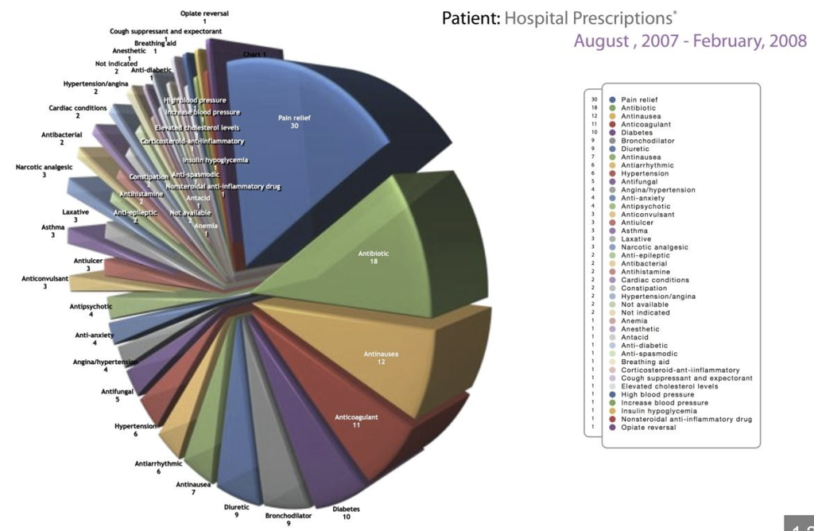

Hospital Prescriptions, Aug 2007 - Feb 2008

```r
#
#
#
#
#
#
#
#
```

## Coding and Decoding

### Exercise 1: Hurricanes

The dataset has one row per hurricane. The variable `deaths` records the number of deaths, and `mf` records whether the hurricane has a female (`"f"`) or male (`"m"`) name. Assume `tidyverse` is loaded and these variables have no missing values.

#### Question 37

A file named `hurricanes.csv` contains one row per hurricane, including its name, year, and number of deaths. The file is in your working directory. Which command loads the data and saves it as an object called `hurricanes`?

**A.** `hurricanes == read.csv("hurricanes.csv")`

**B.** `read.csv("hurricanes.csv")`

**C.** `hurricanes = read.csv("hurricanes.csv")`

**D.** `hurricanes = readRDS("hurricanes.csv")`

#### Question 38

After loading `hurricanes`, which command displays the first six observations, including the values of each variable?

**A.** `summary(hurricanes)`

**B.** `head(hurricanes)`

**C.** `names(hurricanes)`

**D.** `dim(hurricanes)`

#### Question 39

Which code calculates the mean and median number of deaths across all hurricanes?

**A.**

```r
hurricanes |>
  summarize(Mean = mean(deaths), Median = median(deaths))
```

**B.**

```r
hurricanes |>
  select(Mean = mean(deaths), Median = median(deaths))
```

**C.**

```r
hurricanes |>
  group_by(Mean = mean(deaths), Median = median(deaths))
```

**D.**

```r
hurricanes |>
  count(Mean = mean(deaths), Median = median(deaths))
```

#### Question 40

Suppose some hurricanes have missing values (`NA`) for `deaths`. What should you add inside both `mean()` and `median()` to calculate these summaries using only recorded values?

**A.** `drop.na = TRUE`

**B.** `na.rm = TRUE`

**C.** `remove.na = TRUE`

**D.** `na.rm = FALSE`

#### Question 41

Suppose the grouped summary produces the following hypothetical results:

| mf | Mean | Median |
| --- | --- | --- |
| f | 40 | 5 |
| m | 10 | 5 |

Which interpretation is most appropriate?

**A.** Every hurricane with a female name caused more deaths than every hurricane with a male name.

**B.** Hurricanes with female names typically caused exactly four times as many deaths.

**C.** Female names caused hurricanes to become more deadly.

**D.** A few unusually deadly hurricanes could help explain the higher mean for female-named hurricanes.

#### Question 42

To investigate the higher mean for hurricanes with female names, you want to inspect the five deadliest female hurricanes. Which code selects those five hurricanes and displays them from most to fewest deaths?

**A.**

```r
hurricanes |>
  filter(mf == "f") |>
  arrange(deaths) |>
  head(5)
```

**B.**

```r
hurricanes |>
  filter(mf == "f") |>
  head(5) |>
  arrange(desc(deaths))
```

**C.**

```r
hurricanes |>
  filter(mf == "f") |>
  arrange(desc(deaths)) |>
  head(5)
```

**D.**

```r
hurricanes |>
  select(mf == "f") |>
  arrange(desc(deaths)) |>
  head(5)
```

#### Question 43

The variable `mf` contains `"f"` for hurricanes with female names and `"m"` for hurricanes with male names. Which function belongs in the blank to create a new variable called `name_type` containing `"Female"` and `"Male"`?

```r
hurricanes = hurricanes |>
  mutate(name_type = ______(mf == "f", "Female", "Male"))
```

**A.** `if_else`

**B.** `recode`

**C.** `rename`

**D.** `label`

### Exercise 2: Student grades

This exercise is worth 5 points. Consider the code chunk below and answer all four parts:

**2a.** In the code chunk below, comment on what each line does.

```r
library(tidyverse)

dat = readRDS(file="MyData.rds")

dat = dat |>
  filter(college == "Vanderbilt" & class == "PSCI 2300") |>
  select(c(PS1,PS2,PS3)) |>
  summarize(Blah1 = mean(PS1,na.rm=TRUE),
            Blah2 = mean(PS2,na.rm=TRUE),
            Blah3 = mean(PS3,na.rm=TRUE)) |>
  mutate(Goo = (Blah1 + Blah2 + Blah3)/3,
         Moo = Goo)
```

**2b.** How many columns/variables are in the final version of `dat`?

```r
#
```

**2c.** If my original data `dat` contains 1000 observations, how many observations does `dat` have after running this code chunk?

```r
#
```

**2d.** If `PS1`, `PS2`, and `PS3` are problem set grades in PSCI 2300, what does `Goo` represent?

```r
#
#
```

### Exercise 3: Reminder texts and turnout

This exercise is worth 5 points. Answer all eight parts.

A campaign sent reminder texts to some registered voters. The dataset `reminder` has 600 voters and no missing values. `texted` equals 1 if the voter received a text and 0 otherwise. `voted` equals 1 if the voter turned out and 0 otherwise. Of the 200 voters who were texted, 150 voted. Of the 400 voters who were not texted, 200 voted. **The campaign texted voters who had voted in the previous election.**

For parts after 3b, assume `XX` and `YY` have been correctly filled in to calculate **texted minus not texted**.

```r
reminder |>
  group_by(texted) |>
  summarize(N = n(),
            Turnout = mean(voted))

A = reminder |>
  filter(texted == 1) |>
  summarize(Turnout = mean(voted))

B = reminder |>
  filter(texted == 0) |>
  summarize(Turnout = mean(voted))

Gap = XX - YY
set.seed(42)
SampledGaps = NULL

for (i in 1:1000) {
  one_sample = reminder |>
    slice_sample(prop = 1, replace = TRUE)

  one_texted = one_sample |>
    filter(texted == 1) |>
    summarize(Turnout = mean(voted))

  one_not = one_sample |>
    filter(texted == 0) |>
    summarize(Turnout = mean(voted))

  one_gap = tibble(Gap = one_texted$Turnout - one_not$Turnout)

  SampledGaps = bind_rows(SampledGaps, one_gap)
}

SampledGaps |>
  summarize(Lower = quantile(Gap, p = .025),
            Upper = quantile(Gap, p = .975))
```

After filling in `XX` and `YY`, the last block gives the following interval (rounded to three decimal places):

```r
#   Lower Upper
#   0.173 0.325
```

**3a.** Write out the output of the `group_by(texted)` block: how many rows, and the values of `N` and `Turnout` in each.

```r
#
#
#
#
```

**3b.** How should we compute `Gap`? What do `XX` and `YY` need to be?

```r
#
#
#
#
```

**3c.** What does the number 1000 refer to?

```r
#
#
```

**3d.** What is `one_sample`, and how many rows does it contain in each iteration? At the end of the loop, how many rows are in `one_sample`, and how many rows are in `SampledGaps`?

```r
#
#
#
#
```

**3e.** What is `one_texted`? How many observations does it contain?

```r
#
#
#
#
```

**3f.** What is `one_not`?

```r
#
#
```

**3g.** What is `SampledGaps` measuring?

```r
#
#
#
#
```

**3h.** Does the interval suggest that the turnout difference is distinguishable from zero? Given how voters were selected to receive texts, can we conclude that texting causes higher turnout? Explain both answers.

```r
#
#
#
#
```